# Chart Configuration

Jeremy Wildfire

2022-04-08

# Chart Configuration Vignette

The {safetyGraphics} shiny app can be used to display a wide variety of charts. This vignette provides details about the charting process including step-by-step instructions for adding new charts and technical specifications, but first we need to talk about a 2nd package …

# Introducing {safetyCharts}

While this is technically a vignette for {safetyGraphics}, the {safetyCharts} package is just as important here. The roles of the packages can be summarized in just a few words:

**The {safetyGraphics} platform displays charts from {safetyCharts}.**

While {safetyGraphics} and {safetyCharts} are designed to work seamlessly together, users can also add charts from other packages. In fact, several charts in {safetyCharts} are just wrappers that load charts from other packages for use in {safetyGraphics}. The rest of this vignette provides a series of step-by-step examples detailing how this process works for different types of charts.

# {safetyGraphics} Chart Components

To add a chart to safetyGraphics, two components are required:

1. A Configuration Object
2. A Chart Function

The configuration file captures metadata about the chart for use in the app and is typically saved as a YAML file. Several example configuration files are provided in the examples below, and YAML Configuration files for {safetyCharts} are saved [here](https://github.com/SafetyGraphics/safetyCharts/tree/dev/inst/config).

The chart function typically takes a list of `settings` and a list of `data` as inputs and returns a chart object ready to be displayed in the app. Details of charting functions vary somewhat for different chart types, as explained in the examples below.

A full technical specification of this chart configuration framework is provided in Appendix 1.

# Example 1 - Hello World

Once you’ve created the configuration and chart functions, the chart can be added to the app via the `charts` parameter in `safetyGraphicsApp()`. Consider this simple “Hello World” example:

```
# Chart Function
helloWorld <- function(data, settings){
    plot(-1:1, -1:1)
    text(runif(20, -1,1),runif(20, -1,1),"Hello World")
}

# Chart Configuration
helloworld_chart<-list(
    env="safetyGraphics",
    name="HelloWorld",
    label="Hello World!",
    type="plot",
    domain="aes",
    workflow=list(
        main="helloWorld"
    )
)

safetyGraphicsApp(charts=list(helloworld_chart))
```

It’s also easy to add a custom chart to the default charts provided in {safetyCharts} using the `makeChartConfig()` function:

```
charts <- makeChartConfig(packages="safetyCharts") # or just makeChartConfig() since safetyCharts is included by default
charts$helloworld<-helloworld_chart
safetyGraphicsApp(charts=charts)
```

Here’s our Hello World the chart running in the app:

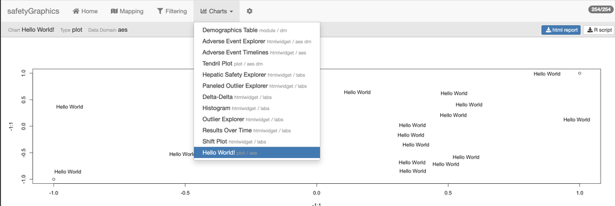

# Example 2 - Static Outlier Explorer

Now let’s consider a more complex example that makes use of the `data` and `settings` provided in `safetyGraphics`. In this section, we use {ggplot2} to create a spaghetti plot for tracking outliers in lab data. First, consider the following code which creates a stand-alone plot for a single data set:

```
# Use sample clinical trial data sets from the {safetyData} package
library(safetyData)
library(ggplot2)
library(dplyr)

# Define data mapping using a format similar to a reactive safetyGraphics mapping
settings <- list(
    id_col="USUBJID",
    value_col="LBSTRESN",
    measure_col="LBTEST",
    studyday_col="LBDY"
)

# Define a plotting function that takes data and settings as inputs
spaghettiPlot <- function( data, settings ){
    # define plot aes - note use of standard evaluation!
    plot_aes <- aes(
        x=.data[[settings$studyday_col]],
        y=.data[[settings$value_col]],
        group=.data[[settings$id_col]]
    )

    #create the plot
    p<-ggplot(data = data, plot_aes) +
        geom_path(alpha=0.15) +
        facet_wrap(
            settings$measure_col,
            scales="free_y"
        )
    return(p)
}

spaghettiPlot(
    safetyData::sdtm_lb %>%
        filter(LBTEST %in% c("Albumin","Bilirubin","Calcium","Chloride")),
    settings
)
```

Running the code above should create a plot with 4 panels:

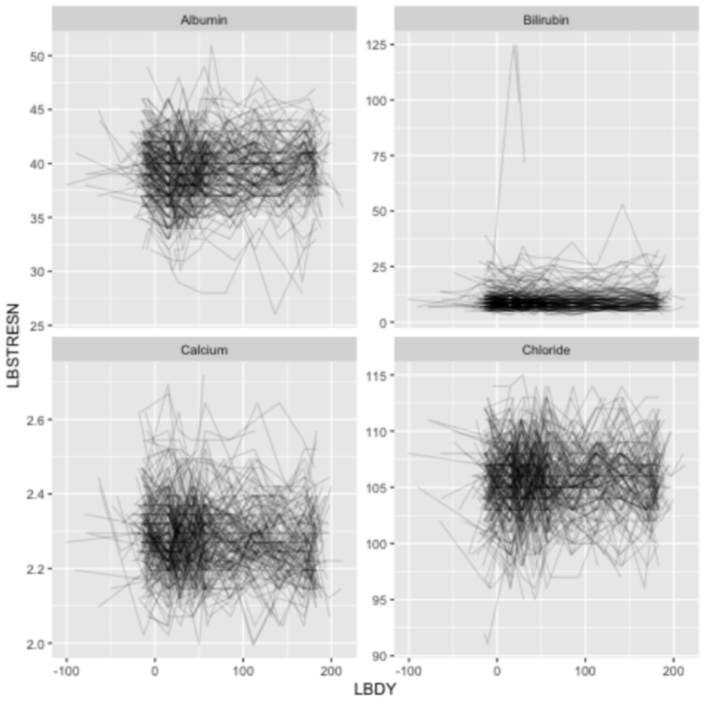

With minor modifications, this chart can be added to the {safetyGraphics} shiny app, which allows us to create the chart with any mappings/data combination loaded in the app. The `spaghettiPlot()` function above is already written to work with safetyGraphics, so we just need to create the chart configuration object. This time we’ll capture the configuration in a [YAML](https://yaml.org/) file.

```
env: safetyGraphics
label: Spaghetti Plot
name: spaghettiPlot
type: plot
domain:
    - labs
workflow:
    main: spaghettiPlot
links:
    safetyCharts: https://github.com/SafetyGraphics/safetycharts
```

With the charting function loaded in to our session and the configuration file saved in our working directory as `spaghetti.yaml`, we can add the chart to the app as follows:

```
library(yaml)
charts <- makeChartConfig()
charts$spaghetti<-prepareChart(read_yaml('spaghetti.yaml'))
safetyGraphicsApp(charts=charts)
```

Under the charts tab, you’ll see:

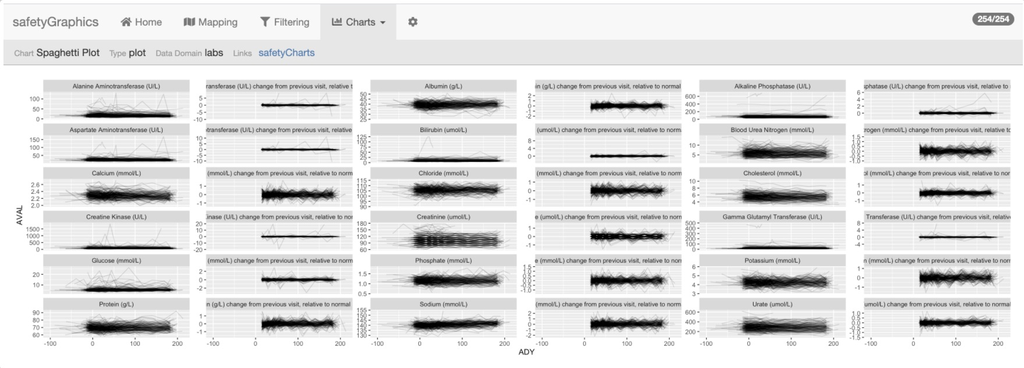

If you look closely at the `spaghettiPlot()` code above, you’ll noticed some details that make the chart work in the app:

- The chart function is written as a function taking `data` and `settings` as inputs. This is the expected parameterization for most charts in {safetyGraphics}.
- The references to `settings` use parameters that are defined on the mapping tab. Behind the scenes, these are defined in the `safetyGraphics::meta`.
- The `spaghettiPlot` function is referenced in the `main` item the YAML `workflow`. This tells the app which function to use to draw the chart.
- We’re using the `.data[[]]` pronoun in the chart function to access columns in the data based on the current settings. See these references for a lot more detail about functional programming in the tidyverse:
  - [Using ggplot2 in packages](https://cran.r-project.org/package=ggplot2/vignettes/ggplot2-in-packages.html)
  - [Programming with dplyr](https://dplyr.tidyverse.org/articles/programming.html)
  - [Functional programming chapters in Advanced R](https://adv-r.hadley.nz/fp.html) These details allow users to dynamically define data attributes for any labs data set, allowing the chart to be reused across many different types of data.

This example is inspired by `safetyCharts::safety_outlier_explorer` - the [charting function](https://github.com/SafetyGraphics/safetyCharts/blob/dev/R/safety_outlier_explorer.R) and [yaml configuration file](https://github.com/SafetyGraphics/safetyCharts/blob/dev/inst/config/safetyOutlierExplorerStatic.yaml) on are GitHub.

# Example 3 - Shiny Module

{safetyGraphics} also supports defining charts as Shiny Modules. Once you’re [familiar](https://shiny.rstudio.com/articles/modules.html) [with](https://mastering-shiny.org/scaling-modules.html) [modules](https://emilyriederer.netlify.app/post/shiny-modules/), they are relatively straightforward to use with safetyGraphics.

Let’s take a look at a simple module that extends the functionality of the static chart from the example above. Once again, this example is based upon `safetyCharts`, and you can see the [code](https://github.com/SafetyGraphics/safetyCharts/blob/dev/R/mod_safetyOutlierExplorer.R) and [config](https://github.com/SafetyGraphics/safetyCharts/blob/dev/inst/config/safetyOutlierExplorerModule.yaml) on GitHub.

```
safetyOutlierExplorer_ui <- function(id) {
    ns <- NS(id)
    sidebar<-sidebarPanel(
        selectizeInput(
            ns("measures"),
            "Select Measures",
            multiple=TRUE,
            choices=c("")
        )
    )
    main<-mainPanel(plotOutput(ns("outlierExplorer")))
    ui<-fluidPage(
        sidebarLayout(
            sidebar,
            main,
            position = c("right"),
            fluid=TRUE
        )
    )
    return(ui)
}
```

Next we define a server function that populates the control for selecting measurements and then draws the plot using [`safetyCharts::safety_outlier_explorer()`](https://github.com/SafetyGraphics/safetyCharts/blob/dev/R/safety_outlier_explorer.R) charting function - which is based on the `spaghetti()` function! Note that the server function takes a single reactive `params` object containing the data (`params$data`) and settings (`param$settings`) as input.

```
safetyOutlierExplorer_server <- function(input, output, session, params) {

    ns <- session$ns
    # Populate control with measures and select all by default
    observe({
        measure_col <- params()$settings$measure_col
        measures <- unique(params()$data[[measure_col]])
        updateSelectizeInput(
            session,
            "measures",
            choices = measures,
            selected = measures
        )
    })

    # customize selected measures based on input
    settingsR <- reactive({
        settings <- params()$settings
        settings$measure_values <- input$measures
        return(settings)
    })

    #draw the chart
    output$outlierExplorer <- renderPlot({safety_outlier_explorer(params()$data, settingsR())})
}
```

```
env: safetyGraphics
label: Outlier Explorer - Module
name: outlierExplorerMod
type: module
package: safetyCharts
domain:
    - labs
workflow:
    ui: safetyOutlierExplorer_ui
    server: safetyOutlierExplorer_server
links:
    safetyCharts: https://github.com/SafetyGraphics/safetycharts
```

Initializing the app as usual by adding it to the chart list: `charts$outlierMod<-prepareChart(read_yaml('outlierMod.yaml'))`

Unselecting a few measures gives the following display:

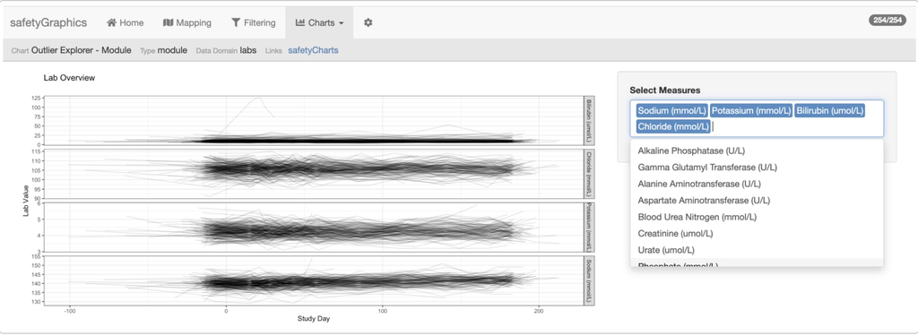

# Example 4 - htmlwidgets and init functions

You can also add custom htmlwidgets to safetyGraphics. In fact, many of the [default charts](https://github.com/SafetyGraphics/safetyCharts/tree/dev/inst/htmlwidgets) imported from safetyCharts are javascript libraries that are imported as htmlwidgets. Like shiny modules, htmlwidgets are relatively simple to use once you are [familiar with the basics](https://www.htmlwidgets.org/).

The biggest differences between widgets and other charts in safetyGraphics are:

1. The widget must be contained in a package, which must be specified in the YAML file.
2. The widget expects a `widget` item giving the name of the widget in the YAML workflow.
3. By default, the data and settings for a widget are passed in a list (`list(data=data, settings=settings)`) to the `x` parameter in `htmlwidget::createWidget`.

Items 1 and 2 above are simple enough, but #3 is likely to create problems unless the widget is designed specifically for usage with safetyGraphics. That is, if the widget isn’t expecting `x$settings` to be a list that it uses to configure the chart, it probably isn’t going to work as expected.

Fortunately, there’s a workaround built in to safetyGraphics in the form of `init` workflow functions. Init functions run before the chart is drawn, and can be used to create custom parameterizations. The init function should take `data` and `settings` as inputs and return `params` which should be a list which is then provided to the chart (see the appendix for more details). The [init function](https://github.com/SafetyGraphics/safetyCharts/blob/dev/R/init_aeExplorer.R) for the the interactive [AE Explorer](https://github.com/RhoInc/aeexplorer) is a good example. It starts by [merging demographics and adverse event data](https://github.com/SafetyGraphics/safetyCharts/blob/c37f3ac7883b15ab3d8a36e597dec85728657fd7/R/init_aeExplorer.R#L16-L18) and then proceeds to [create a customized settings object](https://github.com/SafetyGraphics/safetyCharts/blob/c37f3ac7883b15ab3d8a36e597dec85728657fd7/R/init_aeExplorer.R#L20-L43) to match [the configuration requirements](https://github.com/RhoInc/aeexplorer/wiki/Configuration) of the javascript chart renderer. This init function is then saved under `workflow$init` in the chart config object.

The rest of the [chart configuration YAML](https://github.com/SafetyGraphics/safetyCharts/blob/dev/inst/config/aeExplorer.yaml) is similar to the examples above, and the chart is once again by passing the chart config object to `safetyGraphicsApp()`

# Example 5 - Adding a Chart in a New Data Domain

All of our examples so far have been focused on creating charts in our 3 default data domains (labs, adverse events and demographics), but there is no requirement that limits charts to these three data types. The data domains in the app are determined by a `meta` data frame that defines the columns and fields used in safetyGraphics charts, and customizing `meta` allows us to create charts for any desired data domains.

Generally speaking there are 3 steps to add a chart in a new domain:

1. Create Metadata for a new data domain.
2. Define a chart using the new domain - like the examples above
3. Load data for the new domain

Consider the following example, that modifies a chart from the `labs` domain for use on ECG data:

```
adeg <- readr::read_csv("https://physionet.org/files/ecgcipa/1.0.0/adeg.csv?download")

ecg_meta <-tibble::tribble(
    ~text_key, ~domain,                      ~label,                               ~description, ~standard_adam, ~standard_sdtm,
    "id_col",   "custom_ecg",                 "ID column", "Unique subject identifier variable name.",      "USUBJID",      "USUBJID",
    "value_col",   "custom_ecg",              "Value column",                 "QT result variable name.",         "AVAL",     "EGSTRESN",
    "measure_col",   "custom_ecg",            "Measure column",                 "QT measure variable name",        "PARAM",       "EGTEST",
    "studyday_col",   "custom_ecg",          "Study Day column",                  "Visit day variable name",          "ADY",         "EGDY",
    "visit_col",   "custom_ecg",              "Visit column",                      "Visit variable name",         "ATPT",        "EGTPT",
    "visitn_col",   "custom_ecg",       "Visit number column",               "Visit number variable name",        "ATPTN",             NA,
    "period_col",   "custom_ecg",             "Period column",                     "Period variable name",      "APERIOD",             NA,
    "unit_col",   "custom_ecg",               "Unit column",            "Unit of measure variable name",        "AVALU",     "EGSTRESU"
) %>% mutate(
    col_key = text_key,
    type="column"
)

qtOutliers<-prepare_chart(read_yaml('https://raw.githubusercontent.com/SafetyGraphics/safetyCharts/dev/inst/config/safetyOutlierExplorer.yaml') )
qtOutliers$label <- "QT Outlier explorer"
qtOutliers$domain <- "custom_ecg"
qtOutliers$meta <- ecg_meta

safetyGraphicsApp(
    domainData=list(custom_ecg=adeg),
    charts=list(qtOutliers)
)
```

As of safetyGraphics v2.1, metadata can be saved directly to the chart object using `chart$meta` as shown in the example above.  
Alternatively, metadata can be saved as a data object in the `chart$package` namespace. Chart-specific metadata should be saved as `meta_{chart$name}` while domain-level metadata should be named `meta_{chart$domain}`. It’s fine to use a combination of these approaches as appropriate for your chart. See `?safetyGraphics::makeMeta` for more detail.

# Appendix #1 - Chart Framework Technical Specifications

## Configuration Overview

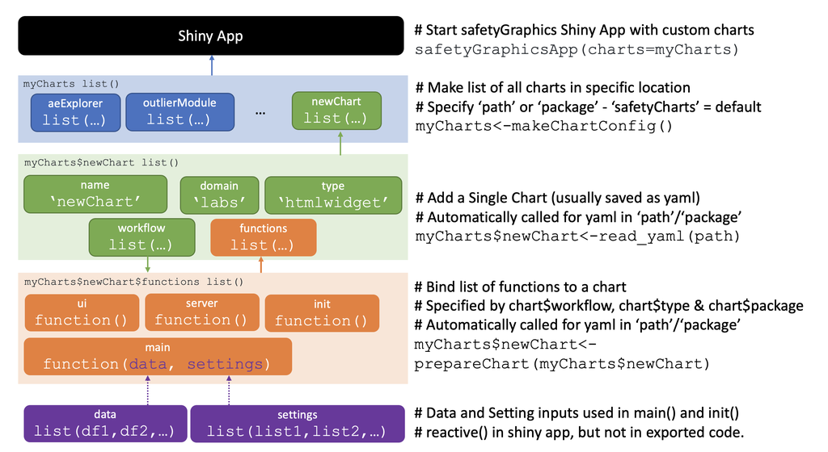

The diagram above summarizes the various components of the safetyGraphics charting framework:

- The `safetyGraphicsApp()` function allows users to specify which charts to include in the shiny app via the `charts` parameter, which expects a `list` of charts.
- Each item in `charts` is itself defined as a `list` that provides configuration details for a single chart. These configuration lists have several required parameters, which are described in the technical specification below.
- Configuration lists are typically saved as YAML files, but can be also be loaded directly as list objects as shown in the Hello World example above.
- Needed functions are bound to the chart object via the prepareChart() function. See the documentation for `chart$functions` below for full details.

## Chart Specification

Each item in the `charts` list should be a list() with the following parameters:

- `env`: Environment for the chart. Must be set to “safetyGraphics” or the chart is dropped. Type: *character*. **Required**
- `name`: Name of the chart. Type: *character*. **Required**
- `type:`: Type of chart. Valid options are: “plot”,“htmlwidget”,“html”,“table” and “module”. Type: *character*. **Required**
- `label`: A short description of the chart. chart$name is used if not provided. Type: *character*. *Optional*
- `domain`: The data domain(s) used in the chart. Type: *character*. **Required**
- `package`: The package where the {htmlwidget} is saved. Type: *character*. **Required** when `chart$type` is “htmlwidget”
- `meta`: Table of chart-specific metadata. Metadata can also be saved as `{package}::meta_{chart}` or `{package::meta_{domain}`. See `?safetyGraphics::makeMeta` for more detail.
- `order`: Order in which to display the chart. If order is a negative number, the chart is dropped. Defaults to 999999. Type: *Integer*. *Optional*
- `links`: Named list of link names/urls to be shown in the chart header. Type: *list of character*. *Optional*
- `path`: Full path of the YAML file. Auto-generated by `makeChartConfig()` Type: *character* *optional*
- `workflow`: Names of functions used to create the chart. Should be loaded in global environment or included in `chart$package` before calling `prepareChart()`. Supported parameters are listed below. Type: *list of character*. **Required**
  - `workflow$main`: name of the function to draw the chart. The function should take `data` and `settings` parameters unless the input parameters are customized by an `init` function. **Required**, unless `chart$type` is “htmlwidget” or “module”)
  - `workflow$init: name of initialization function that runs before chart is drawn via the`main`function. Should take`data`and`settings`as input and return a list of parameters accepted by the`main` function. *Optional*
  - `workflow$widget`: name or widget saved in `chart$package` to be passed to `htmlwidgets::createWidget` **Required** when `chart$type` is “htmlwidget”
  - `workflow$ui` and `workflow$server`: names of functions to render shiny ui and server. Automatically generated in `prepareChart()` unless `chart$type` is “module”. **Required** when `chart$type` is ‘module’
- `functions`: a list of functions used to create the chart. Typically generated at runtime by `prepareChart()` using information in `chart$workflow`, `chart$type` and `chart$package`. Not recommended to generate manually. Type: *list of functions*. **Required**

## Default Technical workflow

This appendix describe the technical process used to render a chart when safetyGraphicsApp() is called with the default parameters.

1. `safetyGraphicsApp()` is called with `charts` and `chartSettingsPath` as NULL (the default).
2. `app_startup` is called, which then immediately calls `makeChartConfig()`.
3. `makeChartConfig()` looks for charts in the safetyCharts package (the default) since no path was specified. The function looks for the package in all current `.libPaths()` and then looks in the `inst/config` folder once the package is found.
4. `makeChartConfig` loads YAML configuration files in the specified directories and saves them to a list. `name` and `path` parameters are added.
5. `makeChartConfig` calls `prepareChart` for each chart configuration. `prepareChart` sets default values for `order`, `name` and `export`, and then binds relevant functions to a `chart$functions` list based on the chart’s `type`, `workflow` and `package`.
6. That list of charts is then returned to `app_startup()` which runs a few actions on each chart:
   - If `chart$functions` is missing, `prepareChart` is called (not relevant in the default workflow, but useful for adding custom charts)
   - If `chart$order` is negative, the chart is dropped with a message.
   - If `chart$env` is not “safetyGraphics”, the chart is dropped with a message.
   - If `chart$domains` has elements not found in the `dataDomains` passed to `app_startup(), the chart is dropped with a message.
   - `charts` are re-ordered based on `chart$order`
7. `app_startup` passes the updated list of charts to `makeMeta` assuming no `meta` object was provided. `makeMeta` combines metadata from all charts in to a single data.frame. Charts can save metadata as `chart.meta`, `{package}::meta_{chart}` or `{package}::meta_{domain}`.
8. `app_startup` returns the list of charts and associated metadata to `safetyGraphicsApp` which then then passes them along to `safetyGraphicsServer` as the `charts` parameter.
9. `safetyGraphicsServer` then creates modules for each chart. First, `UIs` are created via `chartsNav()` which then calls:
   - `makeChartSummary` to create the chart header with links and metadata and …
   - `ChartsTabUI` which then calls `chart$functions$ui` to create the proper UI element based on `chart$type`.
10. Next, `safetyGraphicsServer` draws the charts using `chartsTab()` which:
    - Creates a reactive `params` object containing mappings and data using `makeChartParams()` which:
      - Subsets `domainData` based on `chart$domain`
      - Calls `charts$functions$init` if provided
      - Does custom formatting for `chart$type` of “htmlwidget”
    - Chart is drawn using `chart$functions$server` and `chart$functions$main`
    - Button to download R script is added to header. Script is created by `makeChartExport()`
    - Button to download html report is added to header unless type=“module”. Report template is at “inst/reports/safetyGraphicsReport.Rmd”
11. Finally, `safetyGraphicsServer` passes the charts to `settingsTab`, which uses them to help populate the `charts` and `code` subtabs.